# QML tutorial - Week 3

## 1 Rmarkdown

Last week, you learnt how to use R scripts to save your code.

Keeping track of the code you use for data analysis is a very important aspect of research project managing: not only the code is there if you need to rerun it later, but it allows your data analysis to be **reproducible** (i.e., it can be reproduced by you or other people in such a way that starting with the same data and code you get to the same results).

**Reproducible research**

Research is **reproducible** when the same data and same code return the same results.

R scripts are great for writing code, and you can even document the code (add explanations or notes) with comments (i.e. lines that start with `#`).

But for longer text or complex data analysis reports, R scripts can be a bit cumbersome.

A solution to this is using Rmarkdown files (they have the `.Rmd` extension).

### 1.1 Code… and text!

Rmarkdown is a file format that allows you to mix code and formatted text in the same file.

This means that you can write **dynamic reports** using Rmd files: dynamic reports are just like analysis reports (i.e. they include formatted text, plots, tables, code output, code, etc…) but they are **dynamic** in the sense that if, for example, data or code changes, you can just rerun the report Rmd file and all code output (plots, tables, etc…) is updated accordingly!

You can watch this short video for a quick tour.

[video not shown]

**Dynamic reports in R Markdown**

**R Markdown** is a file type with extension `.Rmd` in which you can write formatted text and code together.

R Markdown can be used to generate **dynamic reports**: these are files that are generated automatically from the R Markdown source, ensuring data and results in the report are always up to date.

### 1.2 Formatting text

R comments in R scripts cannot be formatted (for example, you can’t make bold or italic texts).

Text in Rmd files can be fully formatted using a simple but powerful **mark-up language** called [markdown](https://www.markdownguide.org).

You don’t have to learn markdown all in one go, so I encourage you to just learn it bit by bit, in your time. You can look at the the Markdown Guide for an in-depth intro and/or dive in the [Markdown Tutorial](https://www.markdowntutorial.com) for a hands-on approach.

A few quick pointers (you can test them in the [Markdown Live Preview](https://markdownlivepreview.com)):

- Text can be made italics by enclosing it between single stars: `*this text is in italics*`.
- You can make text bold with two stars: `**this text is bold!**`.
- Headings are created with `#`: `# This is a level-1 heading`. `## This is a level-2 heading`.

**Mark-up, Markdown**

A **mark-up language** is a text-formatting system consisting of symbols or keywords that control the structure, formatting or relationships of textual elements. The most common mark-up languages are HTML, XML and TeX.

**Markdown** is a simple yet powerful mark-up language.

### 1.3 Create an Rmd file

**Important**

When working through these tutorials, always **make sure you are in the course RStudio Project** you just created.

You know you are in an RStudio Project because you can see the name of the Project in the top-right corner of RStudio, next to the light-blue cube icon.

If you see `Project (none)` in the top-right corner, that means **you are not** in an RStudio Project.

To make sure you are in the RStudio project, you can open the project by going to the project folder in File Explorer (Win) or Finder (macOS) and double click on the `.Rproj` file.

To create a new Rmd file, just click on the `New file` button, then `R Markdown...`. (If you are asked to install/update packages, do so.)

[figure not shown]

A window will open. Add a title of your choice and your name, then click `OK`.

[figure not shown]

A new Rmd file will be created and will open in the File Editor panel in RStudio.

**Note** that creating an Rmd file does not automatically saves it on your computer. To do so, either use the keyboard short-cut `CMD+S`/`CTRL+S` or click on the floppy disk icon in the menu below the file tab.

[figure not shown]

Save the file inside the `code/` folder with the following name: `tutorial-w03.Rmd`.

Remember that all the files of your RStudio project don’t live inside RStudio but on your computer. So you can always access them from the Finder or File Explorer!

### 1.4 Parts of an Rmd file

An Rmd file usually has three main parts:

- The preamble (green).
- Code chunks (orange).
- Text (blue).

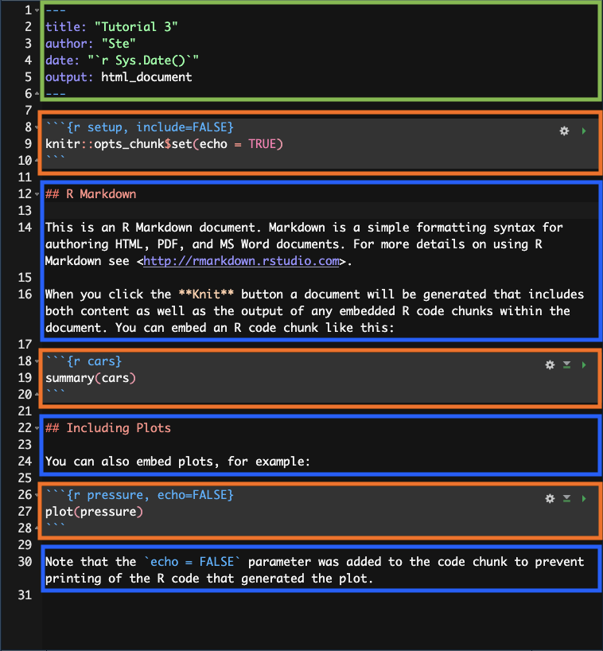

Each Rmd file has to start with a preamble, but you can include as many code chunks and as much text as you wish, in any order.

**R Markdown: Preamble**

The **preamble** of an `.Rmd` file contains a list of `key: value` pairs, used to specify settings or document info like the `title` and `author`.

Preambles start and end with three dashes `---`.

**R Markdown: Code chunks**

**Code chunks** start and end with three back-ticks `` ``` `` and they contain code.

Settings can be specified between curly brackets `{}` on the first `` ``` `` line: for example `{r chunk-name, eval=FALSE}`. `r` indicates that the code is R code.

### 1.5 Render Rmd files to HTML

You can render an Rmd file into a nicely formatted HTML file.

To render an Rmd file, just click on the **Knit** button and an HTML file will be created and saved in the same location of the Rmd file.

[figure not shown]

It will also be shown in the Viewer pane (like in the picture below) or in a new window (you can set this option in the RStudio preferences > R Markdown > Basics > Show output preview in…).

[figure not shown]

Rendering Rmd files is not restricted to HTML, but also PDFs and even Word documents!

This is very handy when you are writing an analysis report you need to share with others.

**R Markdown: Rendering**

Rmd files can be **rendered** into other formats, like HTML, PDF and Word documents.

### 1.6 How to run code

The first code chunk in an Rmd file is a special one: it’s called `setup` and it’s where you attach all the packages needed for running the code in the file. (You can find the name of a code chunk—or define one yourself!—in the first line of a code block: `` ```{r chunk-name} ``). The first code chunk of an Rmd file should always be named `setup`.

The `setup` code chunk also has special code from the knitr package. The knitr package is what allows you to run R code from Rmd files.

The line `knitr::opts_chunk$set(echo = TRUE)` sets the option `echo` to `TRUE`. The `echo` option let’s you decide whether you want the R code printed (echoed) in the rendered Rmd file. When `echo = TRUE` the code is printed, when `echo = FALSE` the code is not printed.

Now go ahead and add `library(tidyverse)` in the line below the `knitr::opts_chunk` line.

**Running code**

To run the code of a code chunk you can use different approaches:

- Click on the green arrow to the right of the code chunk to run the entire code chunk.
- Alternatively, place the text cursor inside the code chunk and press `CMD/CTRL + SHIFT + ENTER`.
- You can also run line by line as you do in an R script by placing the text cursor on the line you want to run and press `CMD/CTRL + ENTER`.

Now delete everything after the `setup` code chunk and write a new level-2 heading after the chunk with the name “Plotting basics”. (Remember to leave an empty line between the chunk and the heading.)

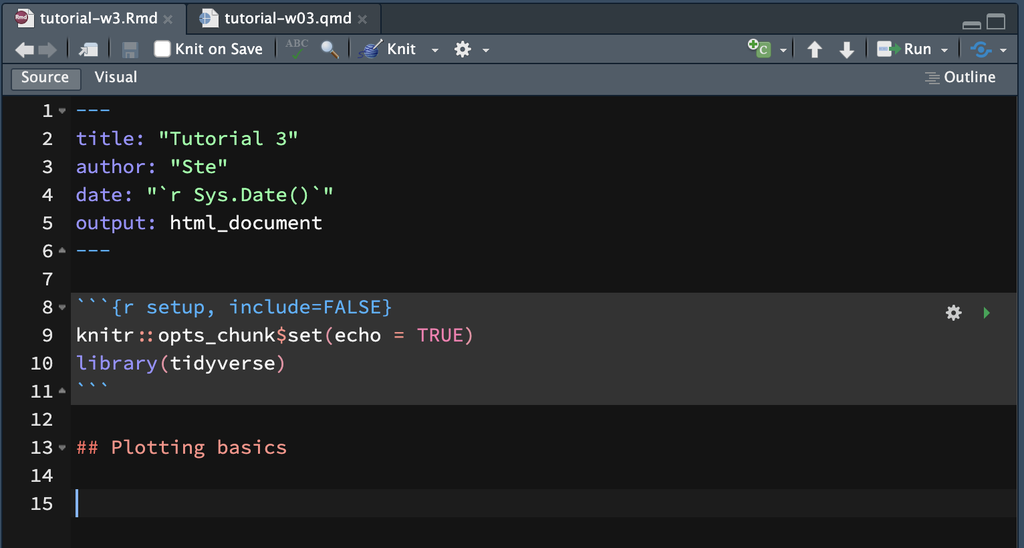

You will use this Rmd file to write text and code for this tutorial. To insert a new code chunk, you can click on the `Insert a new code chunk` button and then select `R`, or you can press `OPT/ALT + CMD/CTRL + I`.

[figure not shown]

A new R code chunk will be inserted at the text cursor position.